# Review of Survival Analysis Concepts

Lecture 7A

PUBHBIO 6250

## Example Data: DPCA Study

- Clinical trial of D-penicillamine (DPCA) on primary biliary cirrhosis (PBC) patients (Dickson et al., 1989).
  - 312 patients randomized to DPCA or control
- **Outcome of interest**: time to death following treatment.
  - In approximately 12.5 years of follow-up, 125 patients died.
- **Main predictors**
  - DPCA treatment (1=DPCA, 0=control)
  - baseline bilirubin level (continuous variable)

## Why Not Linear Regression?

**Problem**: Not all patients died at the time of analysis.

- We do not observe the outcome values for patients who did not die or were lost to follow-up during the study period.
- This is known as **right-censored data**.

  *Example*
  - Say a patient is alive after 2 years of follow-up.
  - All we know is that their time to death is $>$ 2 years.
  - These subjects are “censored at 2 years.”
  - If we treat follow-up time as death time, we **underestimate** the survival time.

## Why Not Logistic Regression?

- We could dichotomize the outcome and fit a logistic regression.
  - $Y=1$ if subject is dead at time of analysis, 0 otherwise.
  - **Logistic regression likely yields biased results.**
- **Problem 1**: Risk of event depends on follow-up time.
  - Patients entered the study at different times.
  - Exposure durations would differ greatly.
  - Patients who entered late had less of an “opportunity” to die during study.
- **Problem 2**: Death status of a patient who is right censored is unknown.

## Survival Analysis

- Survival analysis = **statistical analysis** of **survival time**

  *It is also known as failure-time analysis, time-to-event analysis, etc.*
- Survival time is the time from a well-defined origin to the occurrence of a well-defined event.
- **Difference** between the calendar time origin and the calendar event time.

  *Examples*:
  - Time from heart transplant to death. event = death; time origin = time of heart transplant
  - Time from vaccination to contracting infectious disease. event = infection; time origin = time of vaccination
- Survival analysis includes
  - Estimating median survival time, survival probability at given times, etc.
  - Modeling and predicting survival time by continuous or categorical predictors.

## Survival Function

Survival time is a random variable.

**Survival function**:

$$\begin{aligned}
S(t) &= \Pr(\text{event has not happened by time }t) \\
&= \Pr(\text{survival time } > t)
\end{aligned}$$

**Three properties of survival function**:

1. $S(t)$ decreases with $t$, i.e., probability of surviving decreases over time.
2. $S(0)=1$, i.e., at the initial time, the probability of surviving is 1.
3. If event is death: $S(\infty)=0$, i.e., in the long-run, the probability of not dying is 0.

## Important Concept: “Risk Set” $R(t)$

- $R(t)$ = risk set at follow-up time $t$.
- A subject is in $R(t)$ if they are uncensored and event-free **just prior to $t$** (excludes $t$ itself).
- Thus, a subject is in $R(t)$ if censored or develops event at $t$.

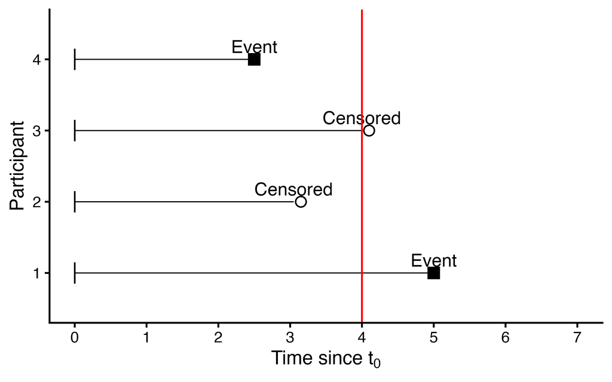

**The risk set at time 4, $R(4)$**

## Review of Kaplan-Meier Estimator

- **Basic idea**: for each unique observation time ($T_k$), compute conditional probability of surviving to that point or beyond given event-free at the previous observation time ($T_{k-1}$).
- To get the probability of surviving up to time $t$ or beyond, take the product of conditional probabilities at observation times $\leq$ $t$.

$$\begin{aligned}
\widehat{S}(t) &=\prod_{T_k\leq t}(\text{proportion event-free among those under follow-up at }T_k) \\
&= \prod_{T_k\leq t}\frac{n_k-d_k}{n_k}
\end{aligned}$$

- $d_k=$ number of events at $T_k$; $n_k=$ size of the risk set at $T_k$

## Review of KM Estimator (Cont’d)

- $\widehat{S}(T_k)=\widehat{S}(T_{k-1})\times\dfrac{n_k-d_k}{n_k}$
  - $\widehat{S}(T_{0})=1$, where $T_0$ is the time origin.
- $\widehat{S}(t)$ is constant between event times.
  - $\widehat{S}(t)=\widehat{S}(T_{k-1})$ for $T_{k-1}\leq t<T_{k}$.
  - If no events occur at $T_k$, $\widehat{S}(T_k)=\widehat{S}(T_{k-1})$.
- Estimator is only defined up to the longest observation time.

**KM Assumptions**

1. Independent event times.
2. Independent censoring.

## Review of Log Rank Test

- Used to compare survival functions of $K\geq2$ groups.
  - $S_j(t)$ = survival probability of group $j$ at time $t$ ($j=1,\ldots,K$).
- **Hypotheses**
  - $H_0:$ $S_1(t)=S_2(t)=\cdots=S_K(t)$ for all $t$ (i.e., all the survival curves are the same at every time point)
  - $H_1:$ Some or all of the survival curves differ at one or more time points.
- Nonparametric test without specifying the distribution of survival time.

**Log Rank Assumptions**

1. Independent event times.
   - Both within and between each group.
2. Independent censoring.

## Review of Log Rank Test (Cont’d)

Let’s focus on **two group case**.

1. **Hypotheses**
   - $H_0:S_1(t)=S_2(t)$ for all t vs. $H_1: S_1(t) \neq S_2(t)$ for some time point $t$
2. **Test statistic**

   $$X = \frac{Z^2}{Var(Z)}$$
   - $Z=$ Total # observed events minus total # expected events for group 1
   - $Var(Z)$ is the variance of $Z$.
3. **Distribution under $H_0$**

   $$\begin{gathered}
   \text{Under } H_0 \text{, } X \sim \chi^2_{1} \\
   p\text{-value} = \Pr(\chi_{1}^{2} > X)
   \end{gathered}$$
4. **Conclusion**: Reject $H_0$ if $X>\chi^2_{1, 1-\alpha}$ or $p$-value $< \alpha$.

## Limitations of Log Rank Test

- Only assesses the effect of one categorical variable on survival function.
- Only answers the question of whether the effect is significant or not, but does not provide an effect size.
- To address these limitations, we want to use a **regression model** like linear and logistic regression.
  - Linear regression models $E(Y)=\beta_0+\beta_1 X$.
  - Logistic regression models $\log \left(\Pr(Y=1)/(1-\Pr(Y=1))\right) = \beta_0+\beta_1 X$.
  - But what do we model for survival data?

## Hazard Function

- **Hazard function $h(t)$** is the instantaneous risk of event at time $t$ among subjects who are event-free at $t$.

  i.e., $h(t)$ = conditional risk of event given that the subject is still at risk of developing the event.
- $h(t)$ is NOT a probability, it is an instantaneous risk.
- $h(t)\ge 0$ but does not have an upper bound.
- Larger $h(t)$ suggests greater risk of event.

## Hazard Function: Formal Mathematical Definition

- Formal mathematical definition:

$$h(t)= \lim_{\Delta t \to 0} \frac{\Pr(t \le T < t + \Delta t \mid T \ge t)}{\Delta t}$$

- $\Pr(t \le T < t + \Delta t \mid T \ge t)$ = conditional probability that an event occurs during the interval $(t, t + \Delta t)$, given that the event has not occurred by time $t$
- $\Delta t$ = length of the interval